# Segmentación de Clientes

Pedro Albarran, curso 2019/2020

## Introducción

Cuando nos relacionamos con clientes, es posible que no queramos dirigir nuestros esfuerzos a un solo grupo. Entender cómo las características afectan a los patrones de compra de los clientes nos ayudará a identificar cómo un segmento de clientes en particular puede ser dirigido en base a sus compras previas en la tienda, patrón de gasto, etc. y así aumentar las ventas generales de la tienda.

La Segmentación de Clientes es una serie de actividades que tienen como objetivo separar grupos homogéneos de clientes (minoristas o comerciales) en subgrupos en función de su comportamiento durante la compra. Por regla general, cada uno de los grupos designados reacciona de forma diferente al producto ofrecido, gracias a lo cual tenemos la oportunidad de ofrecer de forma diferente a cada uno de ellos.

Antes de cada análisis, es esencial declarar explícitamente las preguntas y expectativas sobre los datos y los resultados. Durante el análisis nos gustaría responder a las siguientes preguntas:

1. ¿Qué se espera del análisis?
2. ¿Son los datos disponibles suficientes para las expectativas del análisis?
3. ¿Qué algoritmo se debería utilizar?
4. Hipótesis: Los grupos extraídos permiten diferenciar los clientes de forma visible.
5. ¿Cómo se utilizarán los resultados?

## ¿Qué se espera del análisis?

Disponemos demlos detalles de cada pedido y transacción de una tienda online. Nos gustaría saber más sobre los clientes y averiguar cómo atraerlos y animarlos a utilizar la tienda online en el futuro.

La idea es encontrar grupos de clientes similares en función del comportamiento de compra, luego analizar cada grupo por separado y averiguar lo que es importante para cada usuario al realizar un pedido.

## Datos

Normalmente, los conjuntos de datos de comercio electrónico son propiedad de las empresas y, por consiguiente, son difíciles de encontrar entre los datos disponibles públicamente. Sin embargo, el [“UCI Machine Learning Repository”](http://archive.ics.uci.edu/ml/index.php) ha hecho que este conjunto de datos contenga las transacciones reales de 2010 y 2011. El conjunto de datos se mantiene en su sitio, donde se puede encontrar con el título “Online Retail”.

> “Se trata de un conjunto de datos transnacionales que contiene todas las transacciones realizadas entre el 01/12/2010 y el 09/12/2011 para un comercio minorista en línea no comercial, con sede en el Reino Unido y registrado, que vende principalmente regalos únicos para todas las ocasiones. Muchos clientes de la empresa son mayoristas”.

Los datos contienen las siguientes varibles:

| Variable | Descripción |
| --- | --- |
| InvoiceNo | Número de factura |
| StockCode | Código de inventario |
| Description | Descripción |
| Quantity | Cantidad |
| InvoiceDate | Fecha de factura |
| UnitPrice | Precio por unidad |
| CustomerID | Identificador de Cliente |
| Country | País |

La segmentación de clientes suele explotar información sobre carácteristicas del cliente junto con sus patrones de compra previa. Para comercio a clientes finales, edad, género, capacidad adquisitiva, dónde reside, etc. puden ser características relevantes. En este caso, los clientes son empresas mayoristas por lo que muchas de esas variables no aplican. Quizás nos gustaría conocer más información sobre estas empresas en cualquier caso, pero disponemos solo de una característica relativa a la ubicación del cliente (país).

Importamos los datos y los inspeccionamos.

```r
datos <- read_csv("data/ecommerce.csv")
#str(datos)
glimpse(datos)
```

```
## Rows: 541,909
## Columns: 8
## $ InvoiceNo   <chr> "536365", "536365", "536365", "536365", "536365", "536365"…
## $ StockCode   <chr> "85123A", "71053", "84406B", "84029G", "84029E", "22752", …
## $ Description <chr> "WHITE HANGING HEART T-LIGHT HOLDER", "WHITE METAL LANTERN…
## $ Quantity    <dbl> 6, 6, 8, 6, 6, 2, 6, 6, 6, 32, 6, 6, 8, 6, 6, 3, 2, 3, 3, …
## $ InvoiceDate <chr> "12/1/2010 8:26", "12/1/2010 8:26", "12/1/2010 8:26", "12/…
## $ UnitPrice   <dbl> 2.55, 3.39, 2.75, 3.39, 3.39, 7.65, 4.25, 1.85, 1.85, 1.69…
## $ CustomerID  <dbl> 17850, 17850, 17850, 17850, 17850, 17850, 17850, 17850, 17…
## $ Country     <chr> "United Kingdom", "United Kingdom", "United Kingdom", "Uni…
```

```r
kable(head(datos[,1:4]))
```

| InvoiceNo | StockCode | Description | Quantity |
| --- | --- | --- | --- |
| 536365 | 85123A | WHITE HANGING HEART T-LIGHT HOLDER | 6 |
| 536365 | 71053 | WHITE METAL LANTERN | 6 |
| 536365 | 84406B | CREAM CUPID HEARTS COAT HANGER | 8 |
| 536365 | 84029G | KNITTED UNION FLAG HOT WATER BOTTLE | 6 |
| 536365 | 84029E | RED WOOLLY HOTTIE WHITE HEART. | 6 |
| 536365 | 22752 | SET 7 BABUSHKA NESTING BOXES | 2 |

```r
kable(head(datos[,5:8]))
```

| InvoiceDate | UnitPrice | CustomerID | Country |
| --- | --- | --- | --- |
| 12/1/2010 8:26 | 2.55 | 17850 | United Kingdom |
| 12/1/2010 8:26 | 3.39 | 17850 | United Kingdom |
| 12/1/2010 8:26 | 2.75 | 17850 | United Kingdom |
| 12/1/2010 8:26 | 3.39 | 17850 | United Kingdom |
| 12/1/2010 8:26 | 3.39 | 17850 | United Kingdom |
| 12/1/2010 8:26 | 7.65 | 17850 | United Kingdom |

Calculamos estadísticos de las variables numéricas relevantes

```r
summary(datos[,c(4,6)])
```

|  | Quantity | UnitPrice |
| --- | --- | --- |
|  | Min. :-80995.00 | Min. :-11062.06 |
|  | 1st Qu.: 1.00 | 1st Qu.: 1.25 |
|  | Median : 3.00 | Median : 2.08 |
|  | Mean : 9.55 | Mean : 4.61 |
|  | 3rd Qu.: 10.00 | 3rd Qu.: 4.13 |
|  | Max. : 80995.00 | Max. : 38970.00 |

Comprobamos si existen valores ausentes

```r
datos %>% is.na() %>% summary()
```

|  | InvoiceNo | StockCode | Description | Quantity | InvoiceDate | UnitPrice | CustomerID | Country |
| --- | --- | --- | --- | --- | --- | --- | --- | --- |
|  | Mode :logical | Mode :logical | Mode :logical | Mode :logical | Mode :logical | Mode :logical | Mode :logical | Mode :logical |
|  | FALSE:541909 | FALSE:541909 | FALSE:540455 | FALSE:541909 | FALSE:541909 | FALSE:541909 | FALSE:406829 | FALSE:541909 |
|  | NA | NA | TRUE :1454 | NA | NA | NA | TRUE :135080 | NA |

## Limpieza y transformación de los datos

Borramos todas las cantidades y precios negativos. También tenemos que eliminar las observaciones con valores ausentes del ID de cliente (entre otras)

```r
datos <- datos %>%
  mutate(Quantity = ifelse(Quantity<=0, NA,Quantity),
         UnitPrice = ifelse(UnitPrice<=0, NA, UnitPrice))

datos <- datos %>%
  drop_na()
```

También recodificamos algunas variables:

```r
datos <- datos %>%
  mutate(InvoiceNo=as.factor(InvoiceNo), StockCode=as.factor(StockCode),
         InvoiceDate=as.Date(InvoiceDate, '%m/%d/%Y %H:%M'), CustomerID=as.factor(CustomerID),
         Country=as.factor(Country))
```

Además, necesitamos *transfomar* los datos antes de usarlos.

Siguiendo el método RFM], información útil sobre el comportamiento de compra de un cliente puede ser:

1. Cúan **R**ecientemente ha sido su última compra (en general, su actividad, primera y última compra)
2. **F**recuencia de pedidos.
3. Valor **M**onetario de la cesta (media,mínimo, máximo).

También nos podría interesar la tendencia a cancelar un pedido.

Antes de nada necesitamos calcular el *valor* de la compra:

```r
datos <- datos %>%
  mutate(total_dolar = Quantity*UnitPrice)
```

```r
df_RFM <- datos %>%
  group_by(CustomerID) %>%
  summarise(recency=as.numeric(as.Date("2012-01-01")-max(InvoiceDate)),
            frequency=n_distinct(InvoiceNo), monetary= sum(total_dolar)/n_distinct(InvoiceNo))

summary(df_RFM)
```

|  | CustomerID | recency | frequency | monetary |
| --- | --- | --- | --- | --- |
|  | 12346 : 1 | Min. : 23.0 | Min. : 1.000 | Min. : 3.45 |
|  | 12347 : 1 | 1st Qu.: 40.0 | 1st Qu.: 1.000 | 1st Qu.: 178.62 |
|  | 12348 : 1 | Median : 73.0 | Median : 2.000 | Median : 293.90 |
|  | 12349 : 1 | Mean :115.1 | Mean : 4.272 | Mean : 419.17 |
|  | 12350 : 1 | 3rd Qu.:164.8 | 3rd Qu.: 5.000 | 3rd Qu.: 430.11 |
|  | 12352 : 1 | Max. :396.0 | Max. :209.000 | Max. :84236.25 |
|  | (Other):4332 | NA | NA | NA |

```r
kable(head(df_RFM))
```

| CustomerID | recency | frequency | monetary |
| --- | --- | --- | --- |
| 12346 | 348 | 1 | 77183.6000 |
| 12347 | 25 | 7 | 615.7143 |
| 12348 | 98 | 4 | 449.3100 |
| 12349 | 41 | 1 | 1757.5500 |
| 12350 | 333 | 1 | 334.4000 |
| 12352 | 59 | 8 | 313.2550 |

Sería interesante usar la muy importante variable “Descripción”. Esta contiene información sobre los productos que más interesan a los clientes.

```r
datos %>%
  group_by(Description) %>% filter(row_number()==1) %>% nrow()
```

```
## [1] 3866
```

## Análisis exploratorio

El análisis exploratorio de las tres variables que usaremos se centrará en ver sus estadísticos principales y su distribución. Las relaciones entre ellas son poco relevantes puesto que realizaremos aprendizaje no supervisado.

```r
df_RFM %>% select(recency, frequency, monetary) %>% summary()
```

|  | recency | frequency | monetary |
| --- | --- | --- | --- |
|  | Min. : 23.0 | Min. : 1.000 | Min. : 3.45 |
|  | 1st Qu.: 40.0 | 1st Qu.: 1.000 | 1st Qu.: 178.62 |
|  | Median : 73.0 | Median : 2.000 | Median : 293.90 |
|  | Mean :115.1 | Mean : 4.272 | Mean : 419.17 |
|  | 3rd Qu.:164.8 | 3rd Qu.: 5.000 | 3rd Qu.: 430.11 |
|  | Max. :396.0 | Max. :209.000 | Max. :84236.25 |

Todas las distribuciones tienen grandes colas a la derecha, indicando que algunos clientes tienen valores grandes en ellas (en particular, el valor monetario).

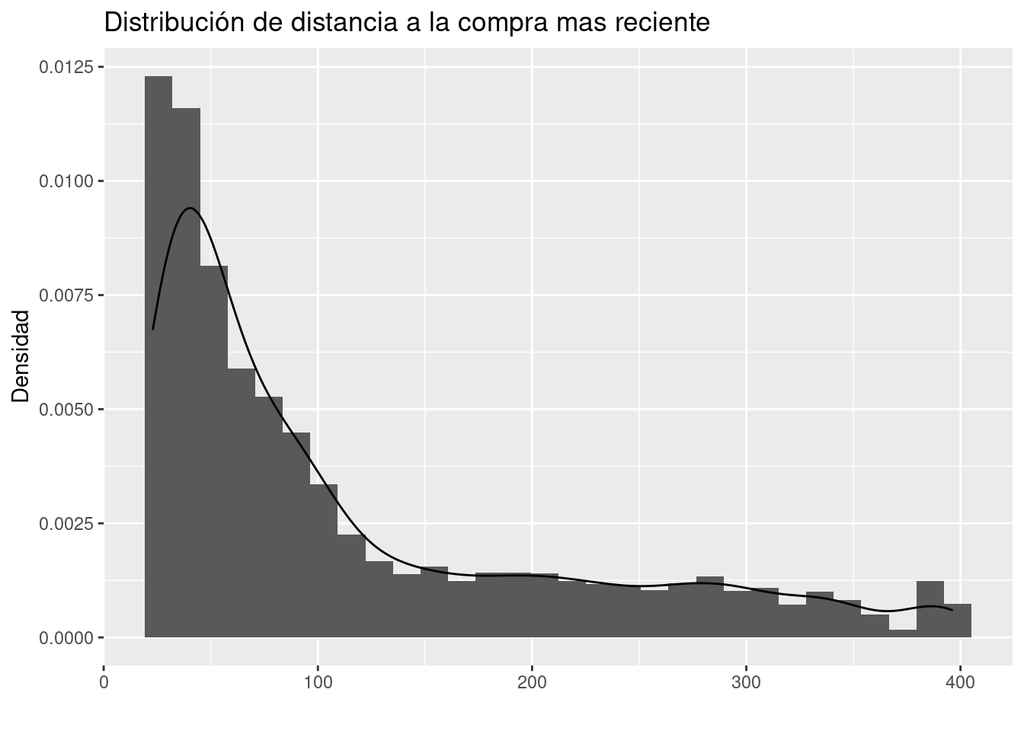

```r
df_RFM %>%  ggplot(aes(x=recency)) + geom_histogram(aes(y=..density..))+ geom_density() + ggtitle("Distribución de distancia a la compra mas reciente") + xlab("") + ylab("Densidad")
```

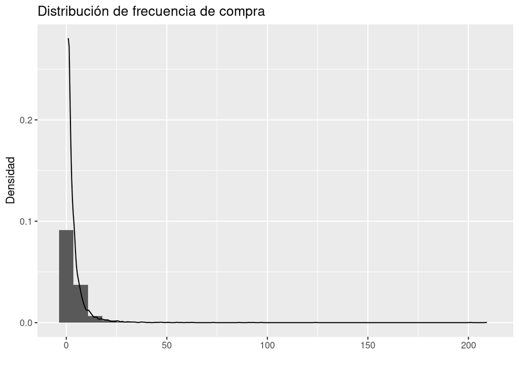

```r
df_RFM %>%  ggplot(aes(x=frequency)) + geom_histogram(aes(y=..density..))+ geom_density() + ggtitle("Distribución de frecuencia de compra") + xlab("") + ylab("Densidad")
```

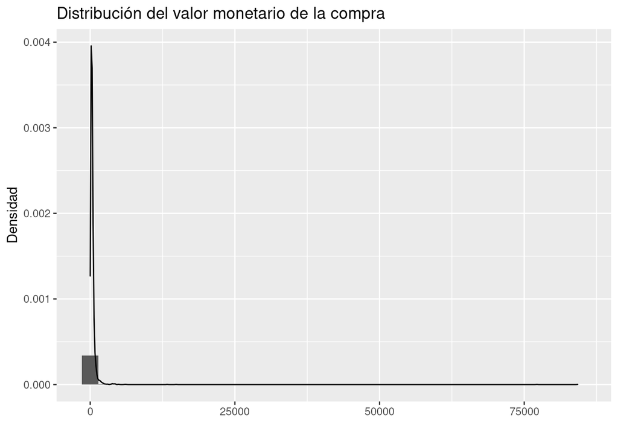

```r
df_RFM %>%  ggplot(aes(x=monetary)) + geom_histogram(aes(y=..density..))+ geom_density() + ggtitle("Distribución del valor monetario de la compra") + xlab("") + ylab("Densidad")
```

Obtendríamos la misma información con gráficos de caja.

Con escala logarítmica, se aprecia algo mejor.

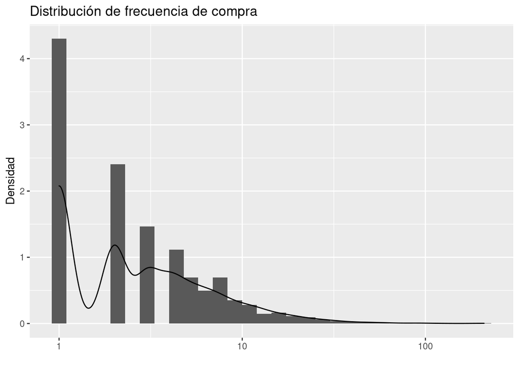

```r
df_RFM %>%  ggplot(aes(x=frequency)) + geom_histogram(aes(y=..density..))+ geom_density() + ggtitle("Distribución de frecuencia de compra") + xlab("") + ylab("Densidad")+scale_x_log10()
```

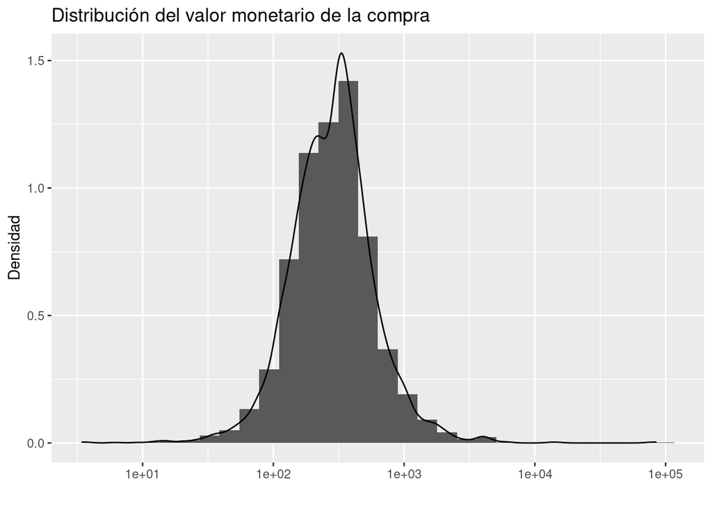

```r
df_RFM %>%  ggplot(aes(x=monetary)) + geom_histogram(aes(y=..density..))+ geom_density() + ggtitle("Distribución del valor monetario de la compra") + xlab("") + ylab("Densidad")+scale_x_log10()
```

En el caso de frecuencia, la forma de la distribución original se debe a una concentración en valores pequeños, con una lenta caida en el frecuencia de valores cada vez más grandes. Para el valor, la forma original se debe a la conocidad log-normalidad de valores de renta, etc.

Un vistazo a las correlaciones, nos muestra una baja relación entre ellas.

```r
df_RFM %>% select(-CustomerID) %>% cor()
```

|  | recency | frequency | monetary |
| --- | --- | --- | --- |
| recency | 1.0000000 | -0.2607832 | -0.0003969 |
| frequency | -0.2607832 | 1.0000000 | 0.0190635 |
| monetary | -0.0003969 | 0.0190635 | 1.0000000 |

## Clustering

Vamos a utilizar el algoritmo k-means para realizar la partición. En primer lugar, debemos seleccionar el número óptimo de grupos mediante el método del codo. Representamos la suma cuadrática total dentro de los grupos para cada valor del número total de clusters, k. Queremos que está sea tan baja como sea posible (lo que implica que los individuos sean parecidos dentro del cluster), pero no existe un óptimo sino que siempre va descender. Por tanto, elegimos un valor de k a partir del cual la caida sea menor.

```r
library(factoextra)
```

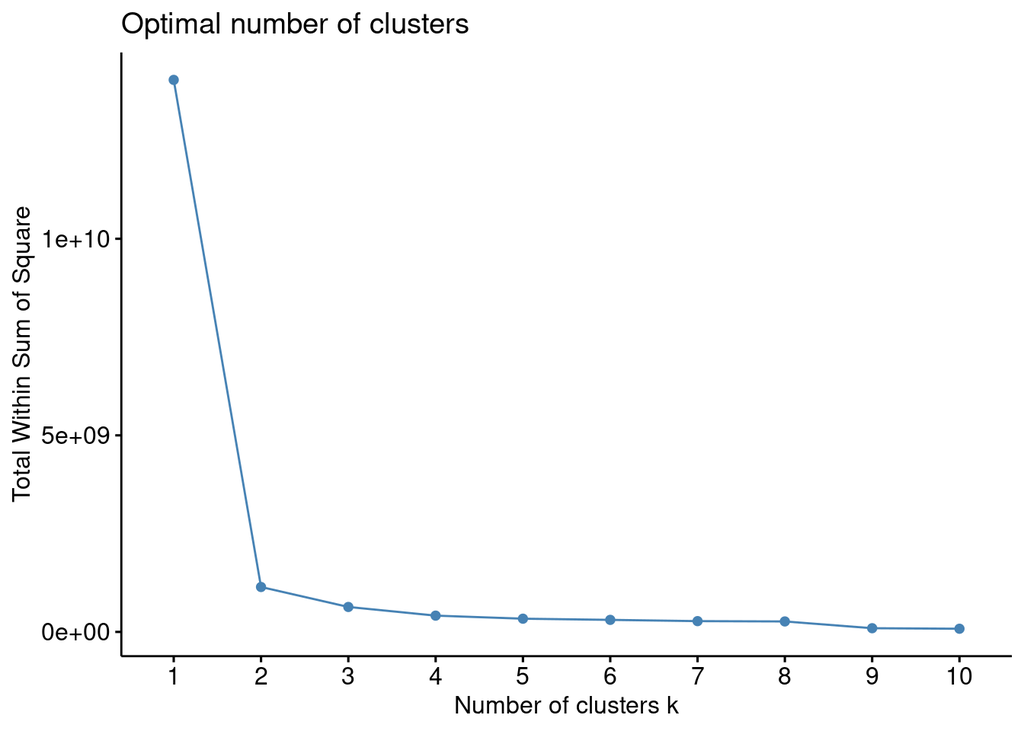

```r
df_RFM %>% select(-CustomerID) %>% fviz_nbclust(kmeans, method = "wss")
```

La selección óptima parece ser dos grupos. Estimamos del modelo

```r
grupos <- df_RFM %>% select(-CustomerID) %>% kmeans(centers=2)

df_RFM$grupo <- grupos$cluster
```

Una vez que hemos identificado los grupos, podemos intentar entender qué tipos de clientes tenemos.

Primero calculamos unos estadísticos descriptivos:

```r
df_RFM %>% filter(grupo==1) %>% select(recency, frequency, monetary) %>% summary()
```

|  | recency | frequency | monetary |
| --- | --- | --- | --- |
|  | Min. : 23.0 | Min. : 1.000 | Min. : 3.45 |
|  | 1st Qu.: 40.0 | 1st Qu.: 1.000 | 1st Qu.: 178.58 |
|  | Median : 73.0 | Median : 2.000 | Median : 293.57 |
|  | Mean :115.0 | Mean : 4.273 | Mean : 382.13 |
|  | 3rd Qu.:164.2 | 3rd Qu.: 5.000 | 3rd Qu.: 429.69 |
|  | Max. :396.0 | Max. :209.000 | Max. :14844.77 |

```r
df_RFM %>% filter(grupo==2) %>% select(recency, frequency, monetary) %>% summary()
```

|  | recency | frequency | monetary |
| --- | --- | --- | --- |
|  | Min. : 23.0 | Min. :1.00 | Min. :77184 |
|  | 1st Qu.:104.2 | 1st Qu.:1.25 | 1st Qu.:78947 |
|  | Median :185.5 | Median :1.50 | Median :80710 |
|  | Mean :185.5 | Mean :1.50 | Mean :80710 |
|  | 3rd Qu.:266.8 | 3rd Qu.:1.75 | 3rd Qu.:82473 |
|  | Max. :348.0 | Max. :2.00 | Max. :84236 |

Vemos la distribución de distancia a la compra más reciente, mediante un diagrama de cajas

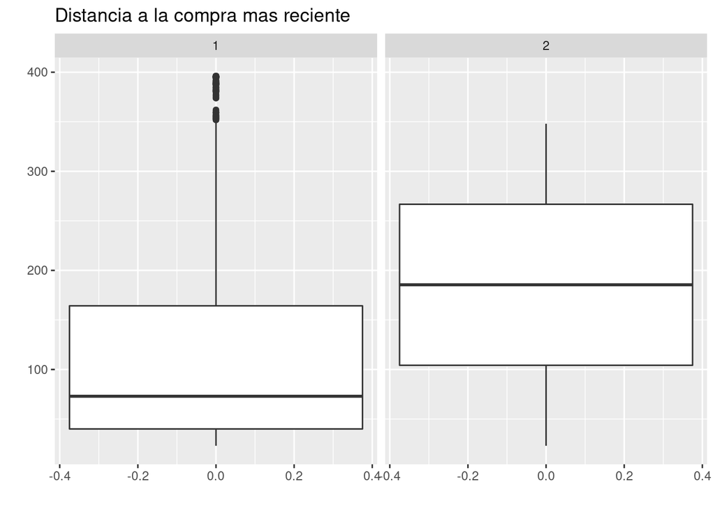

```r
df_RFM %>%  ggplot(aes(y=recency)) + geom_boxplot() + ggtitle("Distancia a la compra mas reciente") + xlab("") + ylab("") + facet_wrap(~grupo)
```

y mediante un histograma y densidad

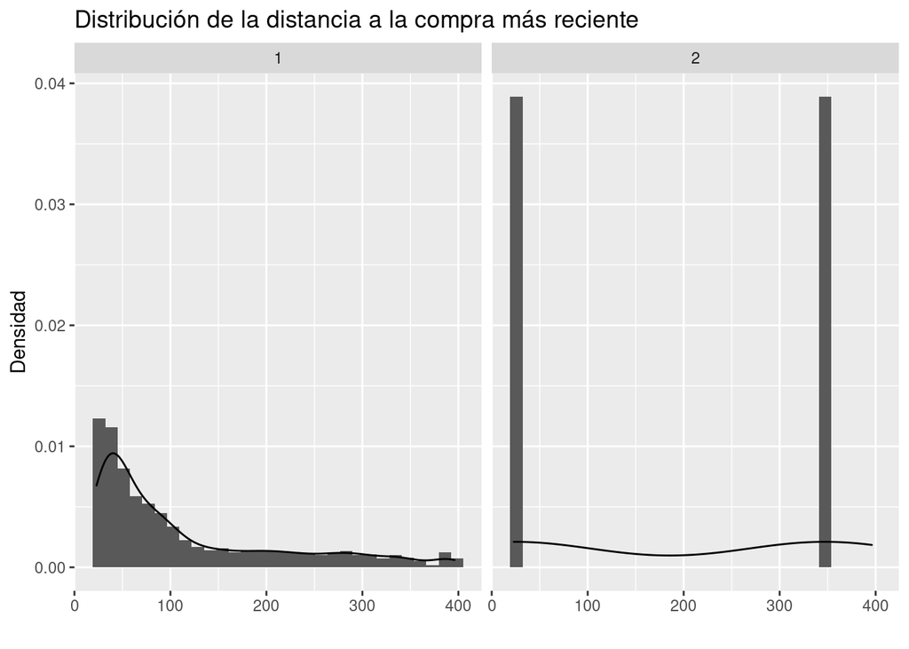

```r
df_RFM %>%  ggplot(aes(x=recency)) + geom_histogram(aes(y=..density..))+ geom_density() + ggtitle("Distribución de la distancia a la compra más reciente") + xlab("") + ylab("Densidad") +  facet_wrap(~grupo)
```

Ahora la distribución para la frecuencia de compra, mediante un diagrama de cajas

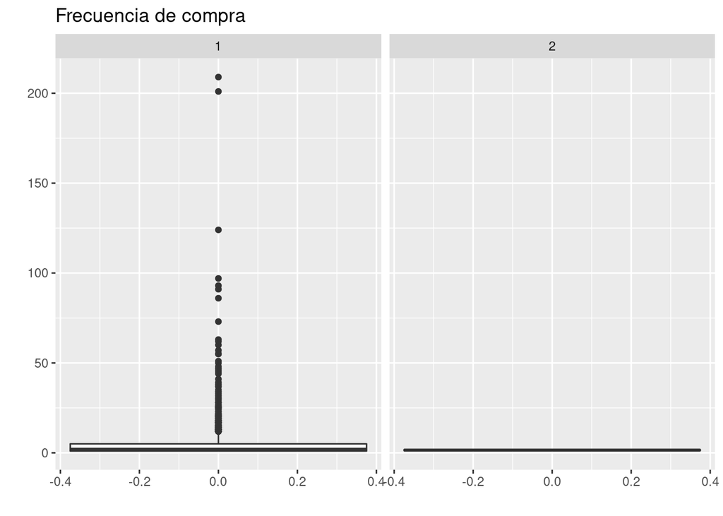

```r
df_RFM %>%  ggplot(aes(y=frequency)) + geom_boxplot() + ggtitle("Frecuencia de compra") + xlab("") + ylab("") + facet_wrap(~grupo)
```

y mediante un histograma y densidad

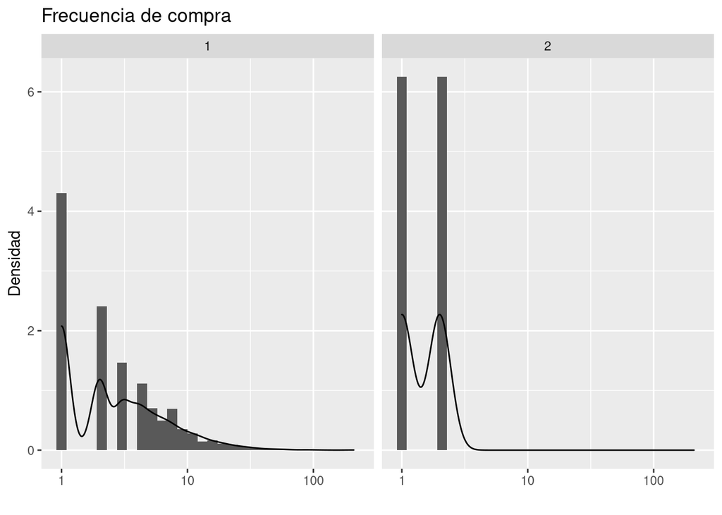

```r
df_RFM %>%  ggplot(aes(x=frequency)) + geom_histogram(aes(y=..density..))+ geom_density() + ggtitle("Frecuencia de compra") + xlab("") + ylab("Densidad") + scale_x_log10() + facet_wrap(~grupo)
```

Finalmente la distribución para el valor de la compra, mediante un diagrama de cajas

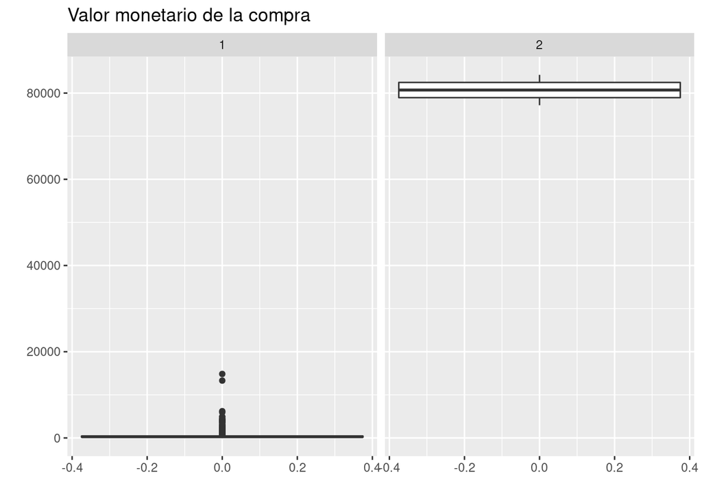

```r
df_RFM %>%  ggplot(aes(y=monetary)) + geom_boxplot() + ggtitle("Valor monetario de la compra") + xlab("") + ylab("") + facet_wrap(~grupo)
```

y mediante un histograma y densidad

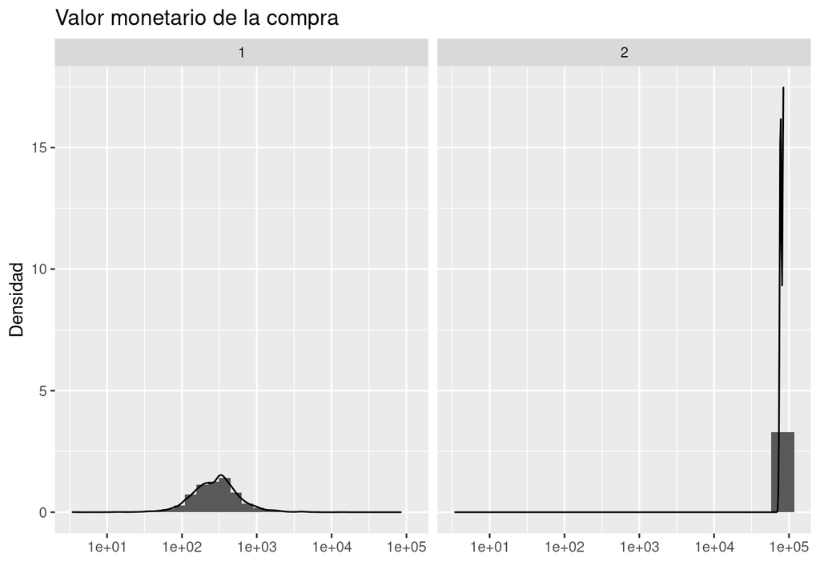

```r
df_RFM %>%  ggplot(aes(x=monetary)) + geom_histogram(aes(y=..density..))+ geom_density() + ggtitle("Valor monetario de la compra") + xlab("") + ylab("Densidad") + scale_x_log10() + facet_wrap(~grupo)
```

## Conclusiones

Hemos aplicado el algoritmo k-means para particionar nuestros clientes en grupos.